# Parse raw data

Tom Smith

Cambridge Centre for Proteomics

26 March, 2022

Abstract

Here we parse the raw data for the total, and succinyl LOPITs.

```r
library(tidyverse)
library(camprotR)
library(MSnbase)
library(here)
```

```r
infile_total_psm <- here("raw/Unmod_PSMs.txt")
infile_succ_psm = here("raw/Suc_PSMs.txt")

protein_fasta_inf <- here("shared_files/Uniprot_Human_Anja_April2019.fasta")

cfasta <- here('shared_files/cRAP_FullIdentifiers.fasta')
```

Make the cRAP list for filtering

```r
bs.fasta <- Biostrings::fasta.index(cfasta, seqtype = "AA")

# Extract the UniProt accessions
crap.accessions <- bs.fasta %>%
  pull(desc) %>%
  stringr::str_extract_all("(?<=\\|).*?(?=\\|)") %>%
  unlist()
```

Parse the PSM level data

```r
raw_psm <- NULL
raw_psm$unmod  <- parse_features(read.delim(infile_total_psm),
                                 TMT=TRUE, level='PSM',
                                 crap_proteins=crap.accessions, unique_master=TRUE)
```

```
Parsing features...
112593 features found from 9035 master proteins => Input
230 cRAP proteins supplied
1020 proteins identified as 'cRAP associated'
111630 features found from 8987 master proteins => cRAP features removed
111171 features found from 8955 master proteins => associated cRAP features removed
111127 features found from 8954 master proteins => features without a master protein removed
105292 features found from 8099 master proteins => features with non-unique master proteins removed
```

```r
raw_psm$succ <- parse_features(read.delim(infile_succ_psm),
                               TMT=TRUE, level='PSM',
                               crap_proteins=crap.accessions, unique_master=TRUE)
```

```
Parsing features...
19182 features found from 2389 master proteins => Input
230 cRAP proteins supplied
411 proteins identified as 'cRAP associated'
18830 features found from 2361 master proteins => cRAP features removed
18715 features found from 2353 master proteins => associated cRAP features removed
18692 features found from 2352 master proteins => features without a master protein removed
17618 features found from 2229 master proteins => features with non-unique master proteins removed
```

```r
raw_psm %>% lapply(dim)
```

```
$unmod
[1] 105292     47

$succ
[1] 17618    55
```

Parse the PTM scores, add filtered_* columns to detail filtering.

```r
# We need to remove some of the modifications from the ptmRS best site probability column
raw_psm$succ$ptmRS.Best.Site.Probabilities_updated <- raw_psm$succ$ptmRS.Best.Site.Probabilities %>%
  strsplit(split = '; ') %>%
  sapply(function(mod_details){
    keep <- !grepl('TMT|Deamidated|Oxidation', mod_details)
    paste(mod_details[keep], collapse='; ')
    })

raw_psm$succ <- parse_PTM_scores(raw_psm$succ, ptm_col="ptmRS.Best.Site.Probabilities_updated", threshold=75)
```

```
Removed 0 Features where the ptm_col value == `Inconclusive data`
Total Features: 17618
Total detected PTMFeatures: 16110
Features passing filter: 15442
Features failing filter: 668
BiPTM/multiPTM Features where some sites fail filter: 3
Total detected sites: 16806
Sites passing filter: 15463
Sites failing filter: 1343
monoPTM passing filter: 15423
biPTM passing filter: 17
multiPTM passing filter: 2
Too many isoforms: 0
```

```r
raw_psm$succ <- raw_psm$succ %>% filter(filtered_score!="") # The filtering doesn't actually take place until this step
raw_psm %>% lapply(dim)
```

```
$unmod
[1] 105292     47

$succ
[1] 15442    61
```

Add the position of the succinylation

```r
raw_psm$succ <- raw_psm$succ %>% add_PTM_positions(protein_fasta_inf)
```

Add the positions of the peptides

```r
raw_psm$succ <- raw_psm$succ %>% add_peptide_positions(protein_fasta_inf)

raw_psm %>% lapply(dim)
```

```
$unmod
[1] 105292     47

$succ
[1] 15442    64
```

Convert to MSnSets

```r
sample_infile = here("raw/samples.tsv")
sample_info <- read.delim(sample_infile) %>% tibble::column_to_rownames('Tag')
sample_info <- sample_info %>% filter(Sample_name!='Total cell lysate')
rownames(sample_info)[10] <- '131'

makeMsnset <- function(obj, sinfo){

  abundance_cols <- colnames(obj)[grepl('Abundance.', colnames(obj))]

  psm_e <- as.matrix(obj[,abundance_cols])
  psm_f <- obj[,setdiff(colnames(obj), abundance_cols)]

  # update the column names to remove the 'Abundance.` prefix
  colnames(psm_e) <- gsub('Abundance.', '', colnames(psm_e))
  print(colnames(psm_e))
  print(rownames(sinfo))
  psm_e <- psm_e[,rownames(sinfo)]

  res <- MSnbase::MSnSet(exprs=psm_e, fData=psm_f, pData=sinfo)

  #res <- res[,pData(res)$Sample_name!='Total cell lysate']

  return(res)
}

psm_res <- raw_psm %>% lapply(function(x) makeMsnset(x, sample_info))
```

```
 [1] "126"  "127N" "127C" "128N" "128C" "129N" "129C" "130N" "130C" "131"
 [1] "126"  "127N" "127C" "128N" "128C" "129N" "129C" "130N" "130C" "131"
 [1] "126"  "127N" "127C" "128N" "128C" "129N" "129C" "130N" "130C" "131"
 [1] "126"  "127N" "127C" "128N" "128C" "129N" "129C" "130N" "130C" "131"
```

```r
psm_res %>% lapply(dim)
```

```
$unmod
[1] 105292     10

$succ
[1] 15442    10
```

Remove features without quantification values

```r
psm_res <- psm_res %>% lapply(function(x){
  x <- x[rowSums(!is.na(exprs(x)))>0, ]
  camprotR:::message_parse(fData(x), 'Master.Protein.Accessions', "features without quantification removed")
  x
})
```

```
104274 features found from 8081 master proteins => features without quantification removed
15282 features found from 2095 master proteins => features without quantification removed
```

```r
psm_res %>% lapply(dim)
```

```
$unmod
[1] 104274     10

$succ
[1] 15282    10
```

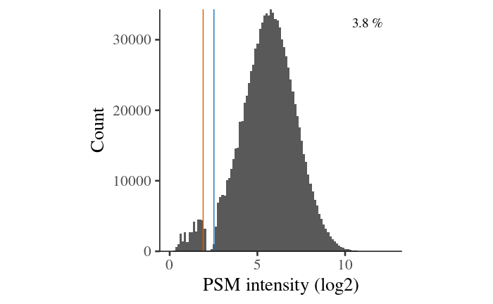

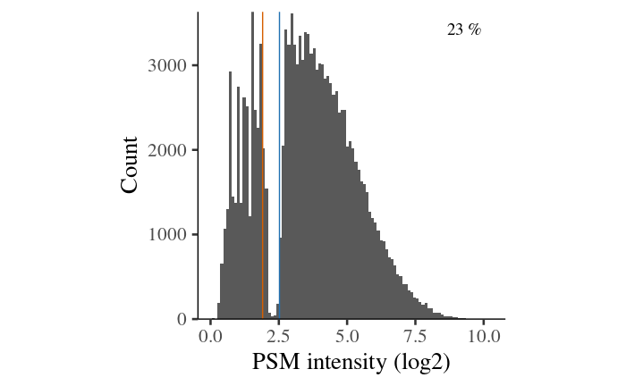

```r
psm_res %>% lapply(plot_TMT_notch)
```

OK, so as expected, with lots of lower intensity PSMs, the notch is more prominent in the succinylation sample, so there will be some underestimation of very low intensities in the succinyl LOPIT (see https://pubs.acs.org/doi/10.1021/acs.jproteome.7b00092 & https://www.biorxiv.org/content/10.1101/2021.07.18.452841v1.full (in print))

Excluding PSMs with SN<5 or interference > 50%

```r
psm_res <- psm_res %>% lapply(function(x) camprotR::filter_TMT_PSMs(x, inter_thresh=50, sn_thresh=5))
```

```
Filtering PSMs...
104274 features found from 8081 master proteins => No quant filtering
97820 features found from 7975 master proteins => Co-isolation filtering
95545 features found from 7953 master proteins => S:N ratio filtering
Filtering PSMs...
15282 features found from 2095 master proteins => No quant filtering
13942 features found from 2012 master proteins => Co-isolation filtering
10627 features found from 1699 master proteins => S:N ratio filtering
```

```r
psm_res %>% lapply(dim)
```

```
$unmod
[1] 95545    10

$succ
[1] 10627    10
```

Note, this also makes the notch less prominent

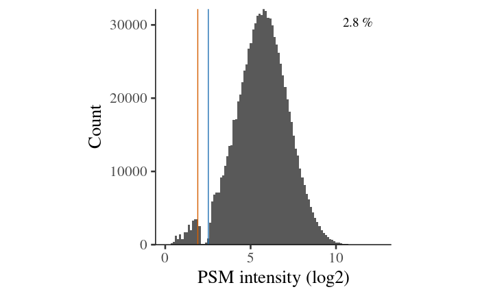

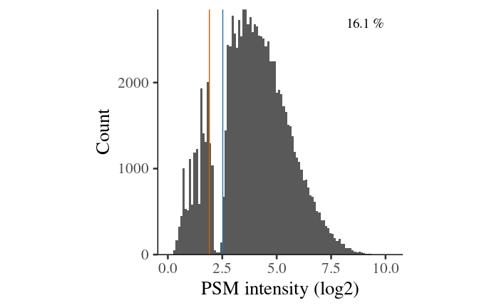

```r
psm_res %>% lapply(plot_TMT_notch)
```

Plot missing values

```
    0     1     2     3     4     5     6     7
91800  2222   795   442   217    59     9     1
```

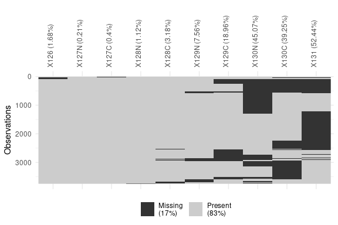

[output not shown]

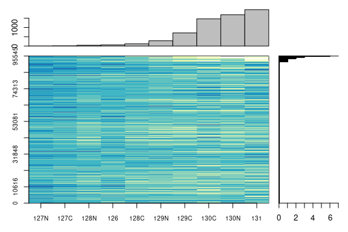

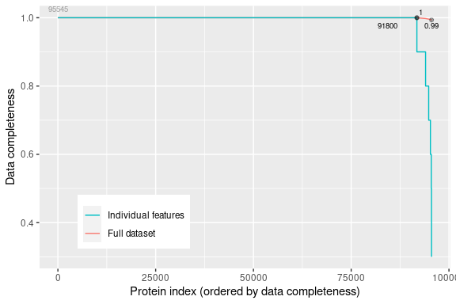

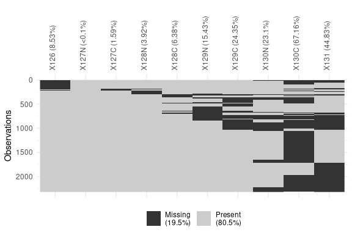

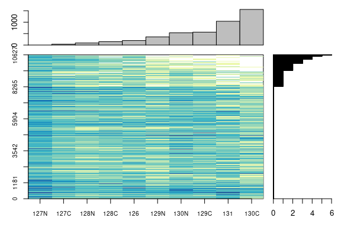

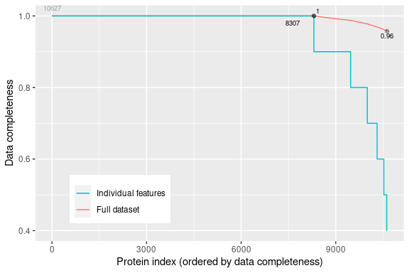

```r
library(RColorBrewer)
psm_res %>% lapply(function(x){

  print(table(rowSums(is.na(exprs(x)))))

  p <- x[rowSums(is.na(exprs(x)))>0,] %>% exprs() %>% data.frame() %>% naniar::vis_miss(cluster=TRUE) + theme(axis.text.x=element_text(angle=90))
  print(p)

  x %>% log(base=2) %>% naplot(col=brewer.pal(n = 8, name = "YlGnBu")[2:8])

  x %>% plotNA(pNA=0) + xlab('PSM index (ordered by data completeness)') + theme_camprot()

  return(NULL)
})
```

OK, so the majority of PSMs have no missing values, even for succinyl LOPIT, but where there are missing values, these are generally in the last fractions. We expect this is just due to values falling below the threshold of detection. In which case, should see relationship to average signal:noise for the PSM as a whole

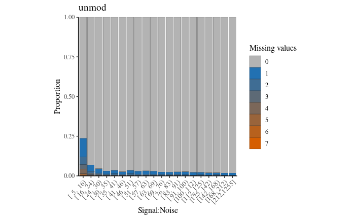

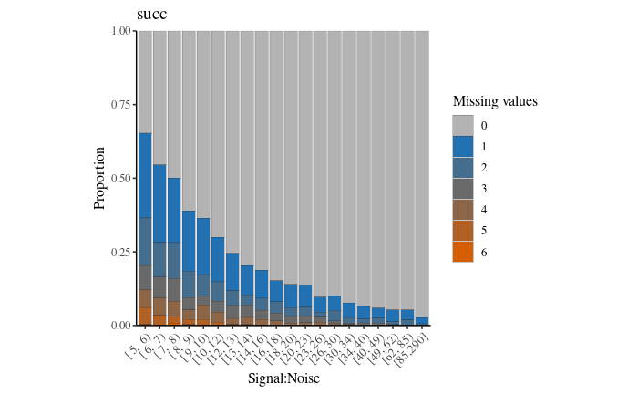

```r
psm_res %>% names() %>% lapply(function(x){
  p <- camprotR::plot_missing_SN(psm_res[[x]]) +
    ggtitle(x)
})
```

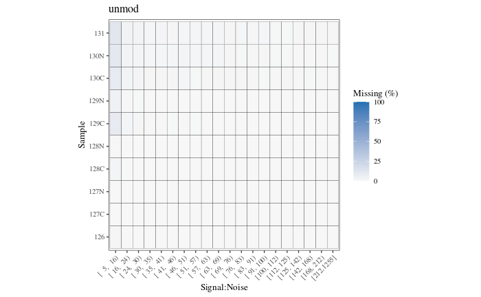

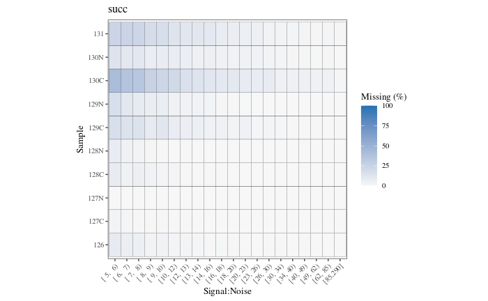

```r
psm_res %>% names() %>% lapply(function(x){
  p <- camprotR::plot_missing_SN_per_sample(psm_res[[x]]) +
    ggtitle(x)
})
```

Yes, looks like missing is due to low intensity.

Below we impute up to three missing values per PSM, using KNN (k=10) after performing sum normalisation on the rows first (to make sure the nearest neighbours have the same profile over the tags, rather than just the same overall intensity). Sum normalisation is reversed after imputation.

```r
library(OptProc)

ImputeMissing <- function(obj, missing=3, method="sn-knn", k=10){
  exprs(obj)[exprs(obj)==0]<- NA
  cat(sprintf("Discarding %s entries with more than %s missing values",
              sum(rowSums(is.na(exprs(obj)))>missing), missing))
  print(dim(obj))
  obj <- obj[rowSums(is.na(exprs(obj)))<=missing,]
  print(dim(obj))

  proteins_with_imputation <- rownames(obj[rowSums(is.na(exprs(obj)))>0,])
  print(length(proteins_with_imputation))

  if(method=="na"){
    obj_impute <- obj
  }
  else{
    sink("/dev/null")
    obj_impute <- OptProc::imputeOptProc(obj, method=method, k=k)
    sink()
  }

  fData(obj_impute)$imputed <- ifelse(rownames(obj_impute) %in% proteins_with_imputation, "Imputed", "Not imputed")
  print(table(fData(obj_impute)$imputed))

  invisible(obj_impute)
}
```

```r
psm_res_imp <- psm_res %>% lapply(ImputeMissing)
```

```
Discarding 286 entries with more than 3 missing values[1] 95545    10
[1] 95259    10
[1] 3459

    Imputed Not imputed
       3459       91800
Discarding 316 entries with more than 3 missing values[1] 10627    10
[1] 10311    10
[1] 2004

    Imputed Not imputed
       2004        8307
```

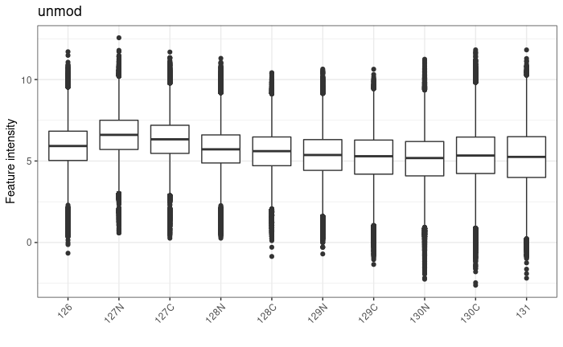

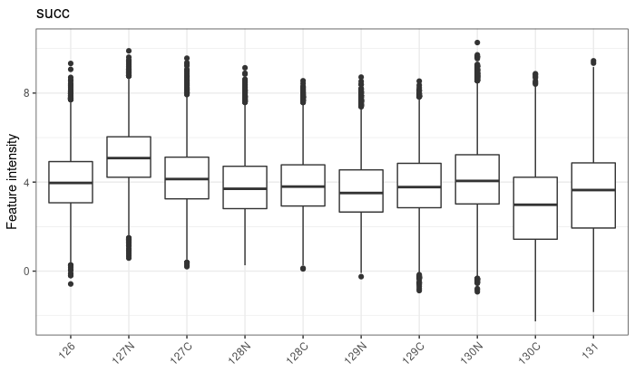

```r
psm_res_imp %>% names() %>% lapply(function(x){
  p <- camprotR::plot_quant(log(psm_res_imp[[x]], base=2)) +
    ggtitle(x)
})
```

Now, let’s center median normalise the PSM level quantification. Note that we don’t need to do this for the downstream analysis but it makes the linear plots more easy to interpret.

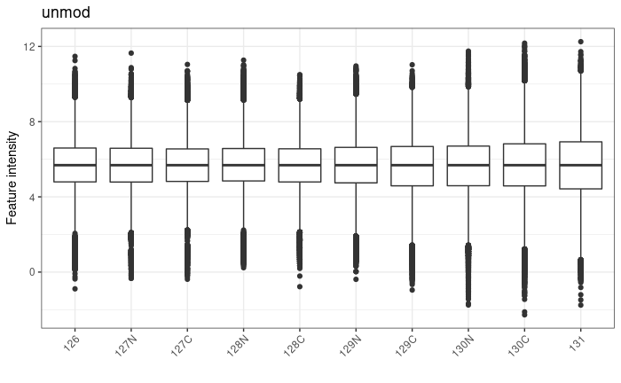

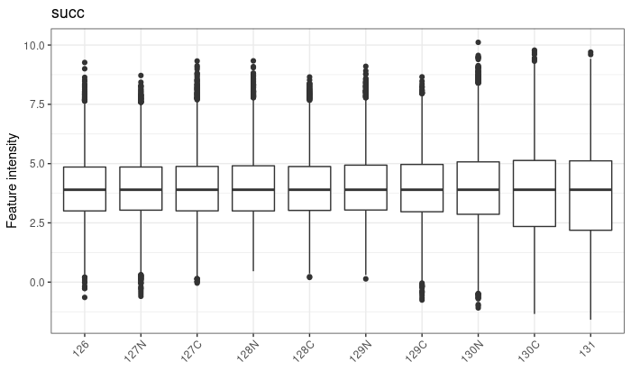

```r
psm_res_imp_cm <- psm_res_imp %>% lapply(function(x){
  cm <- x %>% log(base=2) %>% MSnbase::normalise(method='diff.median')
  exprs(cm) <- 2^(exprs(cm))
  return(cm)
})

psm_res_imp_cm %>% names() %>% lapply(function(x){
  p <- camprotR::plot_quant(log(psm_res_imp_cm[[x]], base=2)) +
    ggtitle(x)
})
```

```r
head(fData(psm_res_imp_cm$succ)$filtered_ptm)
```

```
[1] "Succinyl" "Succinyl" "Succinyl" "Succinyl" "Succinyl" "Succinyl"
```

```r
succ_pep
```

[output not shown]